# Visualize some part of the dataset

```python
import pandas as pd
import numpy as np
import matplotlib.pyplot as plt
import seaborn as sns
%matplotlib inline
```

```python
df = pd.read_csv('twitter_archive_master.csv')
```

## Insight 1 :

○ The 'golden_retriever' dog type is the most common dog that has been rated.

```python
df['Prediction1'].value_counts()
```

```
golden_retriever             556
Labrador_retriever           380
Pembroke                     352
Chihuahua                    316
pug                          216
chow                         164
Samoyed                      160
Pomeranian                   152
toy_poodle                   152
malamute                     116
cocker_spaniel               108
French_bulldog               100
Chesapeake_Bay_retriever      92
miniature_pinscher            88
seat_belt                     84
German_shepherd               80
Siberian_husky                80
Staffordshire_bullterrier     76
Eskimo_dog                    72
Shetland_sheepdog             72
teddy                         72
Maltese_dog                   72
Shih-Tzu                      68
beagle                        68
Cardigan                      68
Rottweiler                    68
Italian_greyhound             64
kuvasz                        64
Lakeland_terrier              64
web_site                      60
                            ...
bonnet                         4
bib                            4
ping-pong_ball                 4
shield                         4
revolver                       4
crash_helmet                   4
fire_engine                    4
school_bus                     4
lawn_mower                     4
nail                           4
sliding_door                   4
lynx                           4
bearskin                       4
studio_couch                   4
carton                         4
hay                            4
mortarboard                    4
dining_table                   4
rotisserie                     4
bighorn                        4
long-horned_beetle             4
picket_fence                   4
bookshop                       4
cup                            4
espresso                       4
marmot                         4
earthstar                      4
bison                          4
leopard                        4
four-poster                    4
Name: Prediction1, Length: 374, dtype: int64
```

###### as we can see that the golden_retriever dog type is the most dog that has been rated in the whole dataset were in the other had there is a lot of dogs types that has just been rated 4 times such as like (four-poster, leopard, bison, earthstar, marmot) , where is sixty dogs has been classified as a 'web_site' :P which shows some flaws in the neural network or it could be just missy data.

## Insight 2 :

○ there is a correlation between the number of tweets and the number of favourites it gets.

```
Text(0.5,1,'scatter plot of retweets and scatter plot')
```

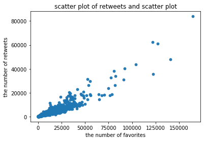

```python
df.plot(kind='scatter',x='favorites',y='retweets', alpha = 0.5)
plt.xlabel('the number of favorites')
plt.ylabel('the number of retweets')
plt.title('scatter plot of retweets and scatter plot')
```

###### as we can see there is a correlation between the number of retweets and the favoirits for every tweet which shows how humans could react more positevly for the tweets or posts that they likes better .

## Insight 3 :

```python
df['rating_numerator'].value_counts()
```

```
12      1796
10      1676
11      1584
13      1044
9        604
8        380
7        208
14       140
5        132
6        128
3         76
4         64
2         36
1         20
0          8
```

[output cut: 20 more lines]

###### it seems like that the most rate has been given to dogs is 12/10 and also that 10/10 is the most second rate has been given , and we can see that 14/10 has been given for just 140 types of dogs.

## Conclusion :

We noticed that the most 10 dog types that has been rated are: golden_retriever , Labrador_retriever, Pembroke , Chihuahua, pug, chow, Samoyed, Pomeranian, toy_poodle, malamute.

We also noticed that when the facourites are going higher the retweets getting higher too... that might be because people who liked a certain tweet they use to engage more with that tweet.

We noticed that the most rate has been put for a dog is 12 , and also that there is exist rating with 'less that 10'.